# HW4

Xuan Wen Loo

2024-02-10

## Problem 1

1. Hypothesis testing is valuable because it can be used to quantify uncertainty. Just because the estimated coefficient is not 0 doesn’t necessarily mean that it is significantly different from 0. There may be false positive or false negative that will lead us to make an incorrect conclusion about the relationships between the predictors and the response. Data scientists rely on hypothesis test to ensure the validity of their findings especially when there are multiple predictors.
2. I disagree with the claim that we could obtain perfect prediction if we know the true f(X). Achieving perfect prediction is not guaranteed due to the inherent variability. This factor is completely random which means even if we have the true f(X), our predictions will still have some uncertainty.
3. False. The statement is incorrect because expected test MSE should be the difference between the true outcome and predicted outcome, where both $y_0$ and $\hat{f}_0$ are from the test set, not from the training set.
4. True. Reducing the complexity of our model such as removing a predictor, may help mitigate overfitting, thereby reducing variance, which could lead to a better performance on unseen data despite potentially introducing some bias.
5. False. Irreducible error represents the inherent randomness in the relationship between predictors and response, which cannot be reduced by any model. Thus, the expected test MSE, which includes both reducible and irreducible error, cannot be smaller than the irreducible error.
6. True. The training MSE is computed using the same data the model was trained on. It measures how well the model fits the training data. Since the model is specifically optimized to minimize the training MSE, it may be possible for the training MSE to be smaller than the irreducible error.

## Problem 2

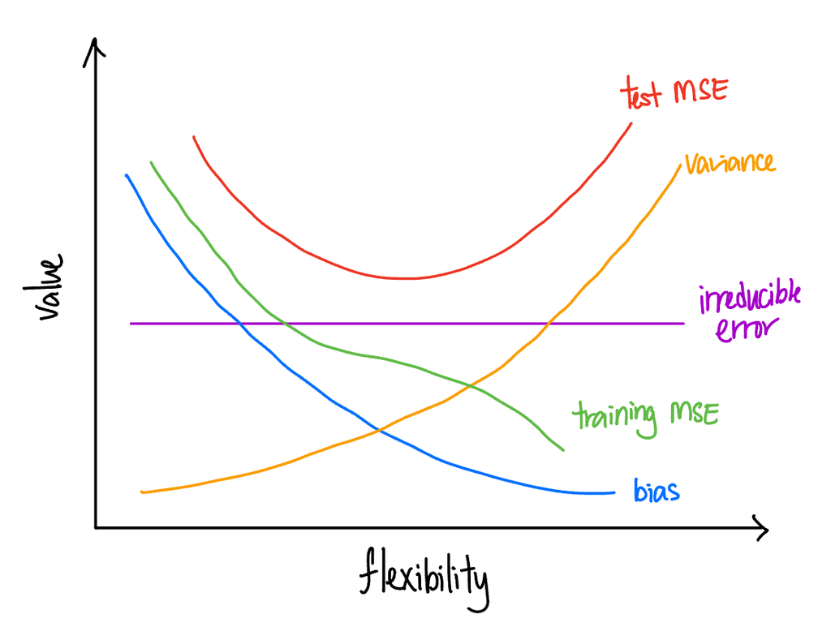

1. Sketch of typical curves